# Pertemuan 2 MPDW - Prak

Uma Keisha Abriana

2026-08-26

# Package

```r
library("forecast")
library("graphics")
library("TTR")
library("TSA")
library("ggplot2")
```

# Data

```r
library(readxl)
data <- read_excel("D:\\SEM 5\\MPDW\\data mpdw prak.xlsx")
head(data)
```

```
## # A tibble: 6 × 2
##   observation_date    CPIAUCSL_PC1
##   <dttm>                     <dbl>
## 1 1978-01-01 00:00:00       681431
## 2 1978-02-01 00:00:00       623946
## 3 1978-03-01 00:00:00       637584
## 4 1978-04-01 00:00:00       650000
## 5 1978-05-01 00:00:00       714286
## 6 1978-06-01 00:00:00       743802
```

# Normalisasikan

```r
str(data)
```

```
## tibble [180 × 2] (S3: tbl_df/tbl/data.frame)
##  $ observation_date: POSIXct[1:180], format: "1978-01-01" "1978-02-01" ...
##  $ CPIAUCSL_PC1    : num [1:180] 681431 623946 637584 650000 714286 ...
```

```r
data$CPIAUCSL_PC1 <- as.numeric(
  gsub(",", "", data$CPIAUCSL_PC1)
)
str(data)
```

```
## tibble [180 × 2] (S3: tbl_df/tbl/data.frame)
##  $ observation_date: POSIXct[1:180], format: "1978-01-01" "1978-02-01" ...
##  $ CPIAUCSL_PC1    : num [1:180] 681431 623946 637584 650000 714286 ...
```

# Mengubah data agar terbaca sebagai data deret waktu dengan fungsi ts()

```r
data.ts <- ts(data$CPIAUCSL_PC1)
data.ts
```

```
## Time Series:
## Start = 1
## End = 180
## Frequency = 1
##   [1]  681431  623946  637584  650000  714286  743802  773026  785597  848287
##  [10]  892857  887097  898876  925040  984127 1025237 1048513 1069767 1107692
##  [19] 1145038 1183612 1187970 1207154 1259259 1325479 1386861 1416185 1459227
##  [28] 1458924 1442577 1426593 1315068 1289009 1276882 1263298 1263158 1235371
##  [37] 1179487 1139241 1061174 1013597  979192  969697 1077482 1081731 1096544
##  [46] 1027155  957944  891204  825688  761364  688488  662177  691193  718232
##  [55]  655738  596529  494092  503212  447761  382572  370763  348469  359029
##  [64]  400000  344108  247423  235897  245650  276356  275229  316327  378710
##  [73]  429009  469388  489297  455466  433468  432596  430862  429570  428287
##  [82]  426587  415430  404339  352595  360624  379009  358180  357488  366442
##  [91]  345821  335249  324737  323501  351377  379147  397351  319849  215356
## [100]  158879  167910  176744  167131  157553  175763  156682  128440  118721
## [109]  136488  191431  284143  367985  366972  374771  392694  428832  427273
## [118]  435572  452899  433213  412926  393560  383244  399290  398230  396476
## [127]  413005  411199  418483  426087  424610  441176  448276  464716  489270
## [136]  503413  527660  516949  506329  462185  443515  458716  465503  463960
## [145]  519802  526316  523732  471162  436540  467365  481928  570281  616987
## [154]  637959  619539  625495  564706  531250  482115  480993  503486  469592
## [163]  436782  379939  339623  284858  306657  298063  267261  281899  318991
## [172]  318283  302360  301471  315712  307467  299270  327988  312046  296671
```

```r
summary(data.ts)
```

```
##    Min. 1st Qu.  Median    Mean 3rd Qu.    Max.
##  118721  358007  448019  580793  724625 1459227
```

# Plot data deret waktu

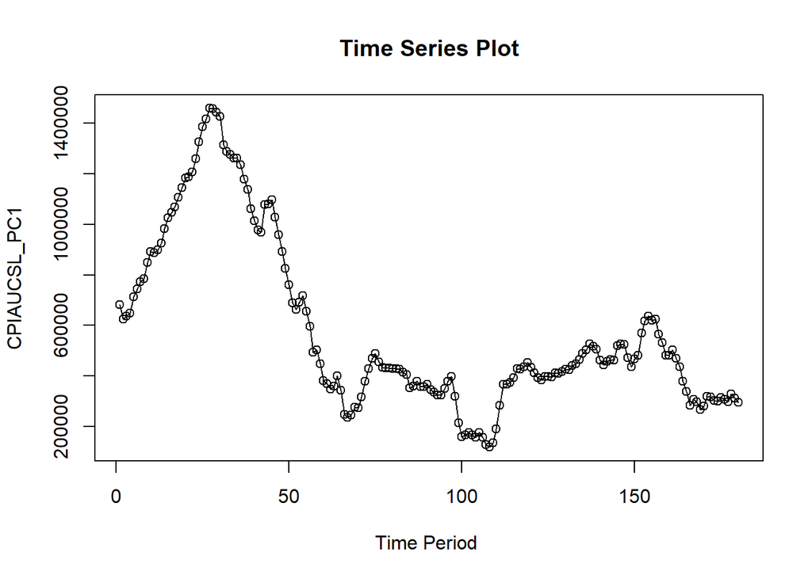

```r
ts.plot(data.ts, xlab="Time Period ", ylab="CPIAUCSL_PC1",
        main = "Time Series Plot")
points(data.ts)
```

# Pembagian Data (Data Latih & Data Uji)

Pembagian data latih dan data uji dilakukan dengan perbandingan 80% data latih dan 20% data uji. Pembagian ini dipakai bersama oleh seluruh metode di bawah, sehingga cukup dijalankan sekali.

```r
# hitung jumlah data
n <- nrow(data)

# tentukan batas 80%
n_train <- floor(0.8 * n)
n_test  <- n - n_train

# bagi data
training <- data[1:n_train, ]
testing  <- data[(n_train+1):n, ]

# ubah ke time series
train.ts <- ts(training$CPIAUCSL_PC1)
test.ts  <- ts(testing$CPIAUCSL_PC1)
```

```r
# cek jumlah data
cat("Jumlah data training :", nrow(training), "\n")
```

```
## Jumlah data training : 144
```

```r
cat("Jumlah data testing  :", nrow(testing), "\n")
```

```
## Jumlah data testing  : 36
```

```r
cat("Total data           :", nrow(training) + nrow(testing), "\n")
```

```
## Total data           : 180
```

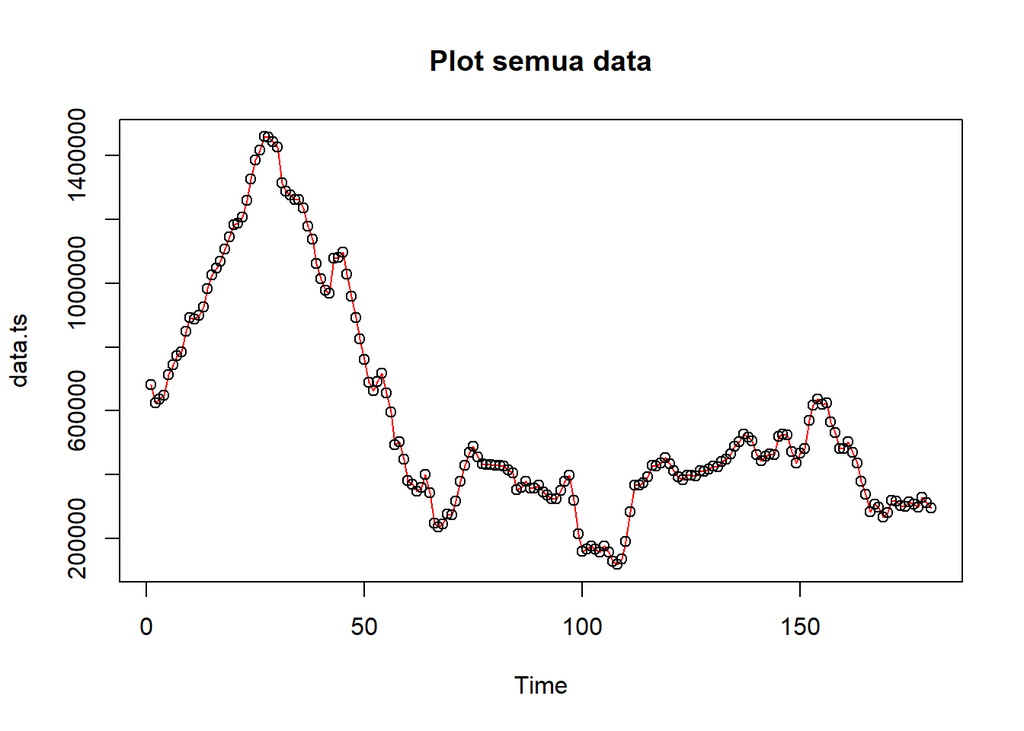

```r
#eksplorasi keseluruhan data
plot(data.ts, col="red", main="Plot semua data")
points(data.ts)
```

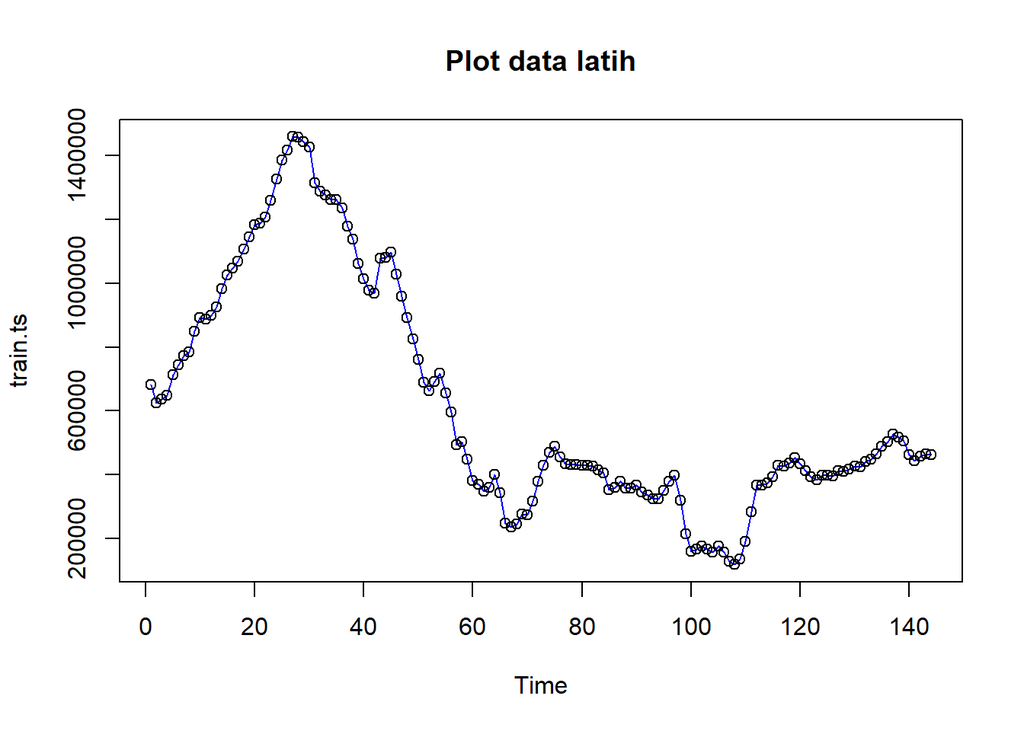

```r
#eksplorasi data latih
plot(train.ts, col="blue", main="Plot data latih")
points(train.ts)
```

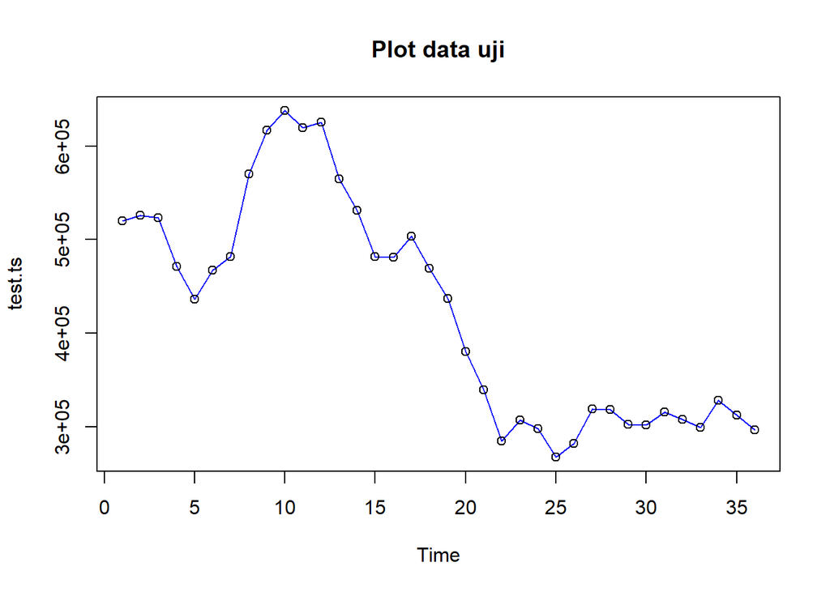

```r
#eksplorasi data uji
plot(test.ts, col="blue", main="Plot data uji")
points(test.ts)
```

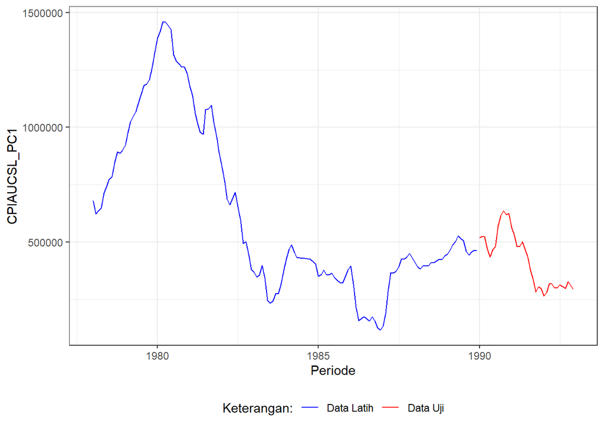

```r
ggplot() +
  geom_line(
    data = training,
    aes(x = observation_date, y = CPIAUCSL_PC1, col = "Data Latih")
  ) +
  geom_line(
    data = testing,
    aes(x = observation_date, y = CPIAUCSL_PC1, col = "Data Uji")
  ) +
  labs(x = "Periode", y = "CPIAUCSL_PC1", col = "Keterangan") +
  scale_colour_manual(
    name = "Keterangan:",
    breaks = c("Data Latih", "Data Uji"),
    values = c("blue", "red")
  ) +
  theme_bw() +
  theme(legend.position = "bottom")
```

# Metode 1: Single Moving Average (SMA)

Ide dasar SMA adalah data pemulusan pada periode ke-t merupakan rata-rata dari m buah data pada periode ke-t hingga periode ke (t-m+1). Metode ini cocok untuk pola data stasioner/konstan.

## Pemulusan

```r
m_sma <- 4   # ubah sesuai kebutuhan
data.sma <- SMA(train.ts, n = m_sma)
data.sma
```

```
## Time Series:
## Start = 1
## End = 144
## Frequency = 1
##   [1]        NA        NA        NA  648240.2  656454.0  686418.0  720278.5
##   [8]  754177.8  787678.0  824941.8  853459.5  881779.2  900967.5  923785.0
##  [15]  958320.0  995729.2 1031911.0 1062802.2 1092752.5 1126527.2 1156078.0
##  [22] 1180943.5 1209498.8 1244965.5 1294688.2 1346946.0 1396938.0 1430299.2
##  [29] 1444228.2 1446830.2 1410790.5 1368311.8 1326888.0 1286064.2 1273086.8
##  [36] 1259677.2 1235328.5 1204314.2 1153818.2 1098374.8 1048301.0 1005915.0
##  [43] 1009992.0 1027025.5 1056363.5 1070728.0 1040843.5  993211.8  925497.8
##  [50]  859050.0  791686.0  734429.2  700805.5  690022.5  681835.0  665423.0
##  [57]  616147.8  562392.8  510398.5  456909.2  426077.0  387391.2  365208.2
##  [64]  369565.2  362901.5  337640.0  306857.0  268269.5  251331.5  258283.0
##  [71]  278390.5  311655.5  349818.8  398358.5  441601.0  460790.0  461904.8
##  [78]  452706.8  438098.0  431624.0  430328.8  428826.5  424968.5  418660.8
##  [85]  399737.8  383247.0  374141.8  362602.0  363825.2  365279.8  356982.8
##  [92]  351250.0  343062.2  332327.0  333716.0  344690.5  362844.0  361931.0
##  [99]  327925.8  272858.8  215498.5  179722.2  167666.0  167334.5  169297.8
## [106]  164282.2  154609.5  144901.5  135082.8  143770.0  182695.8  245011.8
## [113]  302632.8  348467.8  375605.5  390817.2  405892.5  421092.8  436144.0
## [120]  437239.2  433652.5  423149.5  405735.8  397255.0  393581.0  394310.0
## [127]  401750.2  404727.5  409790.8  417193.5  420094.8  427589.0  435037.2
## [134]  444694.5  460859.5  476418.8  496264.8  509323.0  513587.8  503280.8
## [141]  482244.5  467686.2  457479.8  457923.5
```

## Peramalan

Data pemulusan pada periode ke-t digunakan sebagai nilai peramalan pada periode ke t+1.

```r
data.ramal <- c(NA, data.sma)
data.ramal #forecast 1 periode ke depan
```

```
##   [1]        NA        NA        NA        NA  648240.2  656454.0  686418.0
##   [8]  720278.5  754177.8  787678.0  824941.8  853459.5  881779.2  900967.5
##  [15]  923785.0  958320.0  995729.2 1031911.0 1062802.2 1092752.5 1126527.2
##  [22] 1156078.0 1180943.5 1209498.8 1244965.5 1294688.2 1346946.0 1396938.0
##  [29] 1430299.2 1444228.2 1446830.2 1410790.5 1368311.8 1326888.0 1286064.2
##  [36] 1273086.8 1259677.2 1235328.5 1204314.2 1153818.2 1098374.8 1048301.0
##  [43] 1005915.0 1009992.0 1027025.5 1056363.5 1070728.0 1040843.5  993211.8
##  [50]  925497.8  859050.0  791686.0  734429.2  700805.5  690022.5  681835.0
##  [57]  665423.0  616147.8  562392.8  510398.5  456909.2  426077.0  387391.2
##  [64]  365208.2  369565.2  362901.5  337640.0  306857.0  268269.5  251331.5
##  [71]  258283.0  278390.5  311655.5  349818.8  398358.5  441601.0  460790.0
##  [78]  461904.8  452706.8  438098.0  431624.0  430328.8  428826.5  424968.5
##  [85]  418660.8  399737.8  383247.0  374141.8  362602.0  363825.2  365279.8
##  [92]  356982.8  351250.0  343062.2  332327.0  333716.0  344690.5  362844.0
##  [99]  361931.0  327925.8  272858.8  215498.5  179722.2  167666.0  167334.5
## [106]  169297.8  164282.2  154609.5  144901.5  135082.8  143770.0  182695.8
## [113]  245011.8  302632.8  348467.8  375605.5  390817.2  405892.5  421092.8
## [120]  436144.0  437239.2  433652.5  423149.5  405735.8  397255.0  393581.0
## [127]  394310.0  401750.2  404727.5  409790.8  417193.5  420094.8  427589.0
## [134]  435037.2  444694.5  460859.5  476418.8  496264.8  509323.0  513587.8
## [141]  503280.8  482244.5  467686.2  457479.8  457923.5
```

Selanjutnya dilakukan peramalan sebanyak data uji. Pada metode SMA, seluruh hasil peramalan ke depan akan memiliki nilai yang sama dengan hasil ramalan satu periode ke depan.

```r
data.gab.sma <- cbind(
  aktual    = c(data.ts),
  pemulusan = c(data.sma, rep(NA, n_test)),
  ramalan   = c(data.ramal, rep(data.ramal[length(data.ramal)], n_test - 1))
)
data.gab.sma
```

```
##         aktual pemulusan   ramalan
##   [1,]  681431        NA        NA
##   [2,]  623946        NA        NA
##   [3,]  637584        NA        NA
##   [4,]  650000  648240.2        NA
##   [5,]  714286  656454.0  648240.2
##   [6,]  743802  686418.0  656454.0
##   [7,]  773026  720278.5  686418.0
##   [8,]  785597  754177.8  720278.5
##   [9,]  848287  787678.0  754177.8
##  [10,]  892857  824941.8  787678.0
##  [11,]  887097  853459.5  824941.8
##  [12,]  898876  881779.2  853459.5
##  [13,]  925040  900967.5  881779.2
##  [14,]  984127  923785.0  900967.5
```

[output cut: 166 more lines]

## Plot Deret Waktu

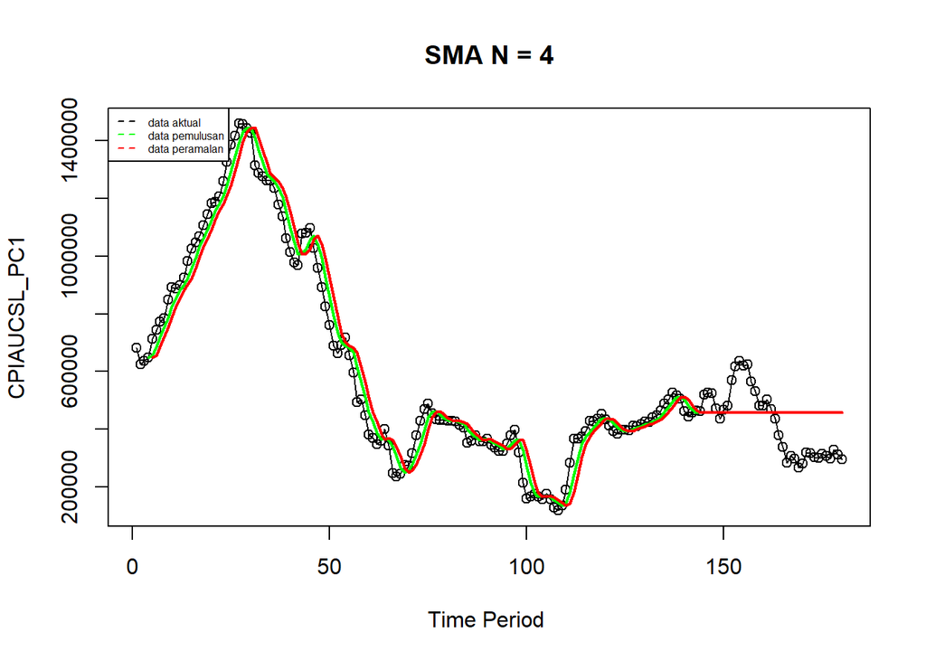

```r
ts.plot(data.ts, xlab="Time Period ", ylab="CPIAUCSL_PC1", main = paste("SMA N =", m_sma))
points(data.ts)
lines(data.gab.sma[,2], col="green", lwd=2)
lines(data.gab.sma[,3], col="red", lwd=2)
legend("topleft", c("data aktual","data pemulusan","data peramalan"), lty=8,
       col=c("black","green","red"), cex=0.5)
```

## Akurasi Data Latih

```r
#Menghitung nilai keakuratan data latih
error_train.sma <- train.ts - data.ramal[1:length(train.ts)]

SSE_train.sma  <- sum(error_train.sma[(m_sma+1):length(train.ts)]^2)
MSE_train.sma  <- mean(error_train.sma[(m_sma+1):length(train.ts)]^2)
MAPE_train.sma <- mean(abs((error_train.sma[(m_sma+1):length(train.ts)]/train.ts[(m_sma+1):length(train.ts)])*100))

akurasi_train.sma <- matrix(c(SSE_train.sma, MSE_train.sma, MAPE_train.sma))
row.names(akurasi_train.sma) <- c("SSE", "MSE", "MAPE")
colnames(akurasi_train.sma)  <- paste("Akurasi m =", m_sma)
akurasi_train.sma
```

```
##      Akurasi m = 4
## SSE   8.210764e+11
## MSE   5.864831e+09
## MAPE  1.235108e+01
```

## Akurasi Data Uji

```r
#Menghitung nilai keakuratan data uji
error_test.sma <- test.ts - data.gab.sma[(n_train+1):n, 3]

SSE_test.sma  <- sum(error_test.sma^2)
MSE_test.sma  <- mean(error_test.sma^2)
MAPE_test.sma <- mean(abs((error_test.sma/test.ts*100)))

akurasi_test.sma <- matrix(c(SSE_test.sma, MSE_test.sma, MAPE_test.sma))
row.names(akurasi_test.sma) <- c("SSE", "MSE", "MAPE")
colnames(akurasi_test.sma)  <- paste("Akurasi m =", m_sma)
akurasi_test.sma
```

```
##      Akurasi m = 4
## SSE   5.447080e+11
## MSE   1.513078e+10
## MAPE  2.969427e+01
```

# Metode 2: Double Moving Average (DMA)

DMA dilakukan dengan memulus ulang hasil SMA, sehingga mampu menangkap data yang memiliki pola tren.

## Pemulusan & Peramalan

```r
dma <- SMA(data.sma, n = m_sma)
At  <- 2*data.sma - dma
Bt  <- 2/(m_sma-1)*(data.sma - dma)
data.dma    <- At + Bt
data.ramal2 <- c(NA, data.dma)

t <- 1:n_test
f <- c()
for (i in t) {
  f[i] <- At[length(At)] + Bt[length(Bt)]*(i)
}

data.gab.dma <- cbind(
  aktual     = c(data.ts),
  pemulusan1 = c(data.sma, rep(NA, n_test)),
  pemulusan2 = c(dma, rep(NA, n_test)),
  At         = c(At, rep(NA, n_test)),
  Bt         = c(Bt, rep(NA, n_test)),
  ramalan    = c(data.ramal2, f[-1])
)
data.gab.dma
```

```
##         aktual pemulusan1 pemulusan2        At          Bt    ramalan
##   [1,]  681431         NA         NA        NA          NA         NA
##   [2,]  623946         NA         NA        NA          NA         NA
##   [3,]  637584         NA         NA        NA          NA         NA
##   [4,]  650000   648240.2         NA        NA          NA         NA
##   [5,]  714286   656454.0         NA        NA          NA         NA
##   [6,]  743802   686418.0         NA        NA          NA         NA
##   [7,]  773026   720278.5   677847.7  762709.3  28287.2083         NA
##   [8,]  785597   754177.8   704332.1  804023.4  33230.4583  790996.52
##   [9,]  848287   787678.0   737138.1  838217.9  33693.2917  837253.90
##  [10,]  892857   824941.8   771769.0  878114.5  35448.5000  871911.23
##  [11,]  887097   853459.5   805064.2  901854.8  32263.5000  913563.00
##  [12,]  898876   881779.2   836964.6  926593.9  29876.4167  934118.25
##  [13,]  925040   900967.5   865287.0  936648.0  23787.0000  956470.29
##  [14,]  984127   923785.0   889997.8  957572.2  22524.7917  960435.00
```

[output cut: 166 more lines]

## Plot Deret Waktu

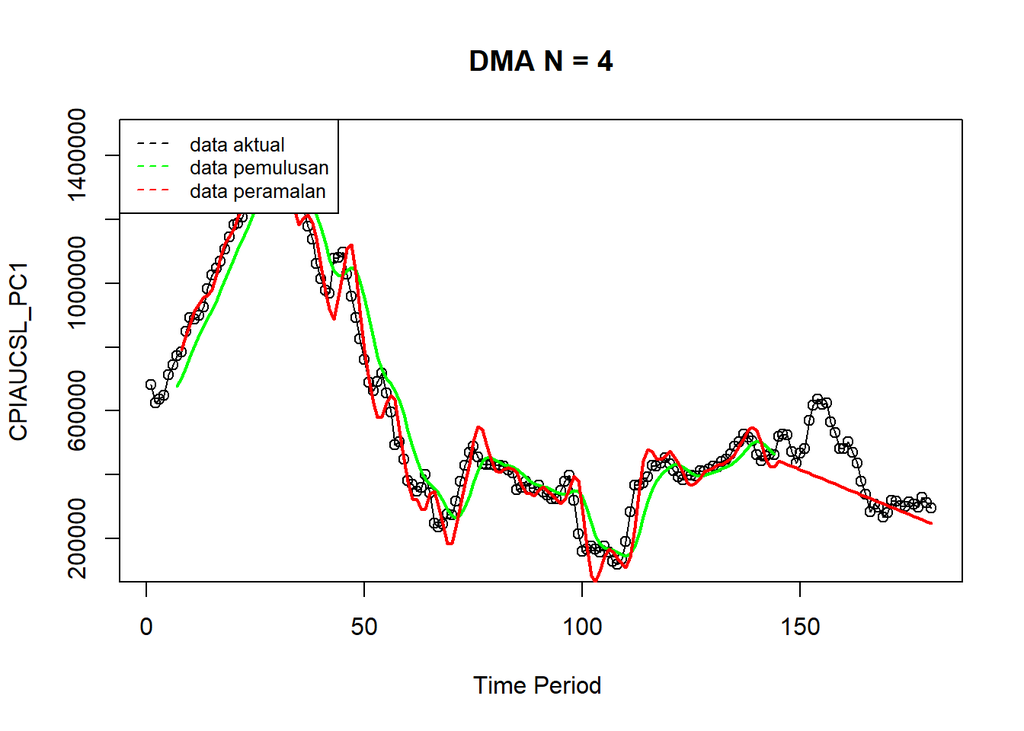

```r
ts.plot(data.ts, xlab="Time Period ", ylab="CPIAUCSL_PC1", main = paste("DMA N =", m_sma))
points(data.ts)
lines(data.gab.dma[,3], col="green", lwd=2)
lines(data.gab.dma[,6], col="red", lwd=2)
legend("topleft", c("data aktual","data pemulusan","data peramalan"), lty=8,
       col=c("black","green","red"), cex=0.8)
```

## Akurasi Data Latih

```r
#Menghitung nilai keakuratan data latih
error_train.dma <- train.ts - data.ramal2[1:length(train.ts)]

start_dma <- 2*m_sma
SSE_train.dma  <- sum(error_train.dma[start_dma:length(train.ts)]^2)
MSE_train.dma  <- mean(error_train.dma[start_dma:length(train.ts)]^2)
MAPE_train.dma <- mean(abs((error_train.dma[start_dma:length(train.ts)]/train.ts[start_dma:length(train.ts)])*100))

akurasi_train.dma <- matrix(c(SSE_train.dma, MSE_train.dma, MAPE_train.dma))
row.names(akurasi_train.dma) <- c("SSE", "MSE", "MAPE")
colnames(akurasi_train.dma)  <- paste("Akurasi m =", m_sma)
akurasi_train.dma
```

```
##      Akurasi m = 4
## SSE   5.290384e+11
## MSE   3.861594e+09
## MAPE  1.090013e+01
```

## Akurasi Data Uji

```r
#Menghitung nilai keakuratan data uji
error_test.dma <- test.ts - data.gab.dma[(n_train+1):n, 6]

SSE_test.dma  <- sum(error_test.dma^2)
MSE_test.dma  <- mean(error_test.dma^2)
MAPE_test.dma <- mean(abs((error_test.dma/test.ts*100)))

akurasi_test.dma <- matrix(c(SSE_test.dma, MSE_test.dma, MAPE_test.dma))
row.names(akurasi_test.dma) <- c("SSE", "MSE", "MAPE")
colnames(akurasi_test.dma)  <- paste("Akurasi m =", m_sma)
akurasi_test.dma
```

```
##      Akurasi m = 4
## SSE   4.372846e+11
## MSE   1.214679e+10
## MAPE  1.769813e+01
```

# Metode 3: Single Exponential Smoothing (SES)

SES memberi bobot yang menurun secara eksponensial pada data lama, sehingga data terbaru diberi bobot lebih besar. Cocok untuk data dengan pola stasioner/konstan. Ada dua cara membangun SES: fungsi `ses()` dari package `forecast`, atau fungsi `HoltWinters()` dari package `stats`.

## Cara 1: fungsi ses()

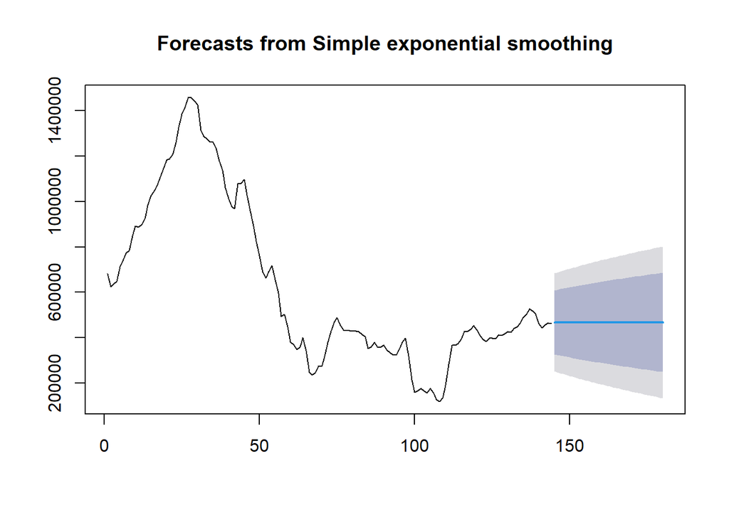

```r
h_forecast <- n_test

ses.1 <- ses(train.ts, h = h_forecast, alpha = 0.2)
plot(ses.1)
```

```r
ses.1
```

```
##     Point Forecast    Lo 80    Hi 80    Lo 95    Hi 95
## 145       468116.8 327134.8 609098.9 252503.5 683730.2
## 146       468116.8 324342.8 611890.9 248233.5 688000.2
## 147       468116.8 321604.0 614629.7 244044.8 692188.9
## 148       468116.8 318915.5 617318.2 239933.1 696300.6
## 149       468116.8 316274.6 619959.1 235894.1 700339.6
## 150       468116.8 313678.8 622554.9 231924.2 704309.5
## 151       468116.8 311125.9 625107.8 228019.9 708213.8
## 152       468116.8 308613.9 627619.8 224178.2 712055.5
## 153       468116.8 306140.8 630092.9 220395.9 715837.8
## 154       468116.8 303705.0 632528.7 216670.6 719563.1
## 155       468116.8 301304.7 634929.0 212999.7 723234.0
## 156       468116.8 298938.4 637295.3 209380.8 726852.9
## 157       468116.8 296604.8 639628.9 205811.8 730421.9
## 158       468116.8 294302.5 641931.2 202290.8 733942.9
```

[output cut: 22 more lines]

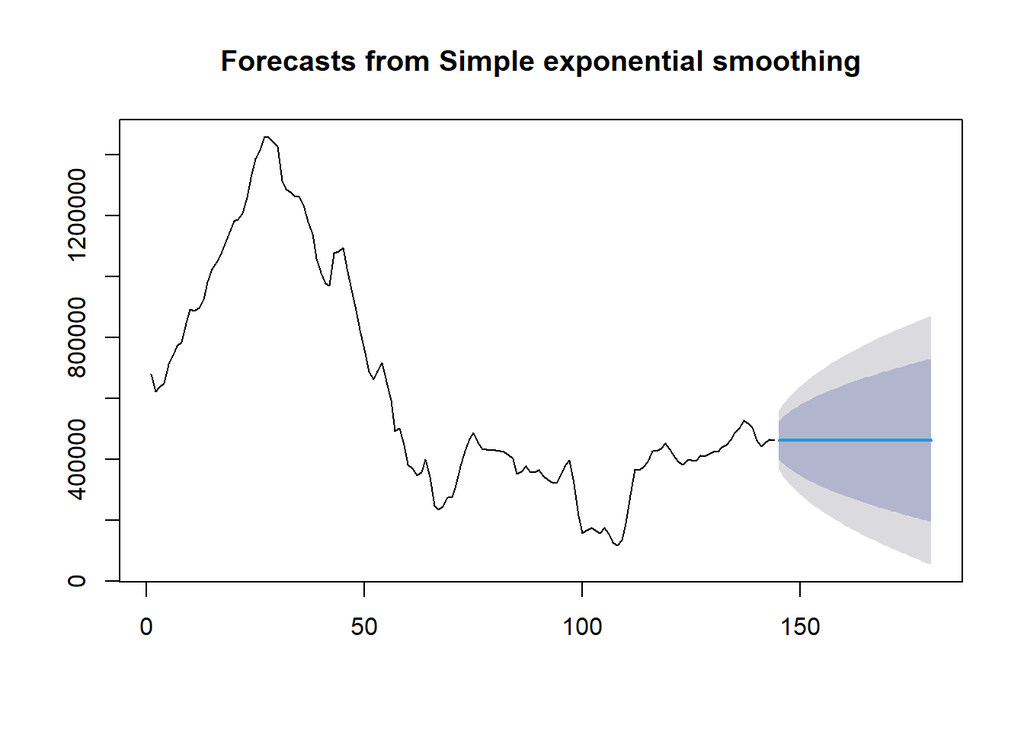

```r
ses.2 <- ses(train.ts, h = h_forecast, alpha = 0.7)
plot(ses.2)
```

```r
ses.2
```

```
##     Point Forecast    Lo 80    Hi 80     Lo 95    Hi 95
## 145       463668.2 401010.3 526326.0 367841.27 559495.1
## 146       463668.2 387184.5 540151.8 346696.53 580639.8
## 147       463668.2 375500.8 551835.6 328827.76 598508.6
## 148       463668.2 365193.6 562142.7 313064.37 614272.0
## 149       463668.2 355867.5 571468.8 298801.33 628535.0
## 150       463668.2 347286.4 580050.0 285677.59 641658.8
## 151       463668.2 339295.9 588040.4 273457.20 653879.2
## 152       463668.2 331788.7 595547.7 261975.87 665360.5
## 153       463668.2 324686.3 602650.0 251113.81 676222.5
## 154       463668.2 317929.7 609406.6 240780.47 686555.9
## 155       463668.2 311472.8 615863.6 230905.43 696430.9
## 156       463668.2 305278.9 622057.5 221432.61 705903.7
## 157       463668.2 299318.2 628018.2 212316.55 715019.8
## 158       463668.2 293566.3 633770.1 203519.74 723816.6
```

[output cut: 22 more lines]

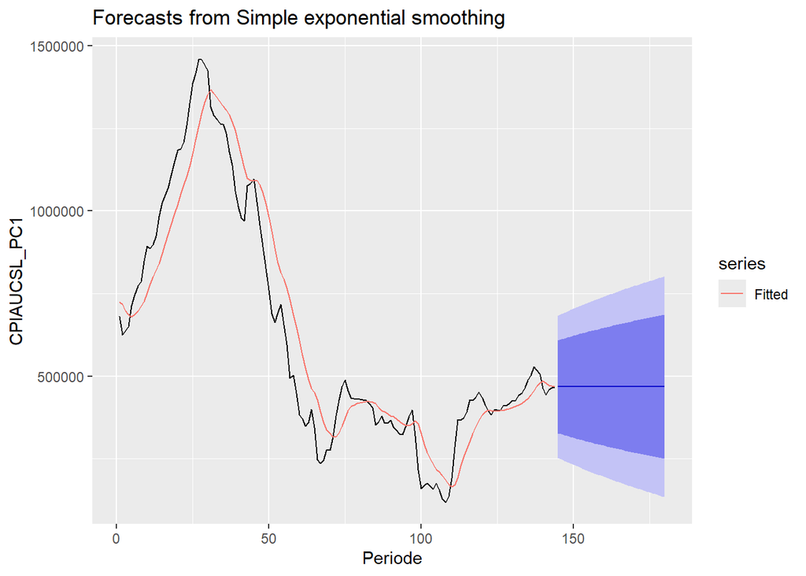

```r
autoplot(ses.1) +
  autolayer(fitted(ses.1), series="Fitted") +
  ylab("CPIAUCSL_PC1") + xlab("Periode")
```

## Cara 2: fungsi HoltWinters()

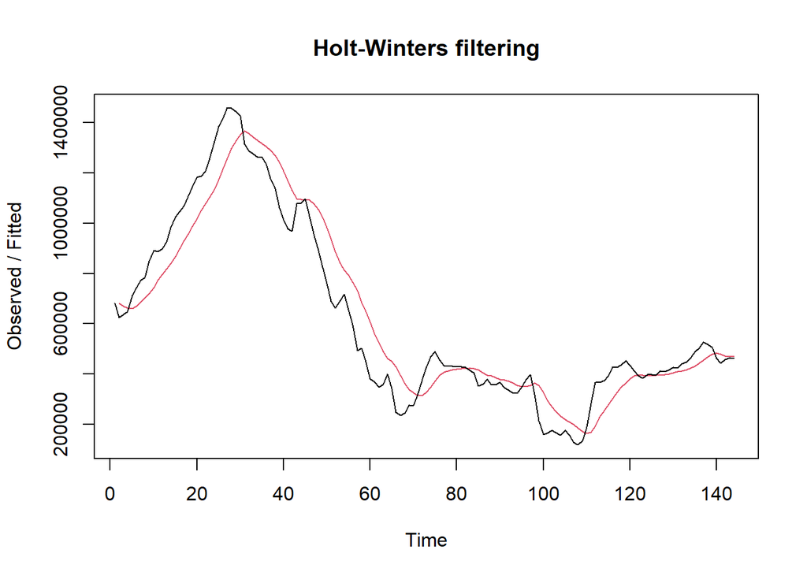

```r
ses1 <- HoltWinters(train.ts, gamma = FALSE, beta = FALSE, alpha = 0.2)
plot(ses1)
```

```r
ramalan1 <- forecast(ses1, h = h_forecast)
ramalan1
```

```
##     Point Forecast    Lo 80    Hi 80    Lo 95    Hi 95
## 145       468116.8 327241.9 608991.8 252667.2 683566.5
## 146       468116.8 324452.0 611781.7 248400.5 687833.2
## 147       468116.8 321715.3 614518.4 244215.0 692018.7
## 148       468116.8 319028.8 617204.9 240106.4 696127.3
## 149       468116.8 316389.9 619843.8 236070.5 700163.2
## 150       468116.8 313796.1 622437.6 232103.6 704130.1
## 151       468116.8 311245.2 624988.5 228202.3 708031.4
## 152       468116.8 308735.1 627498.6 224363.4 711870.3
## 153       468116.8 306263.9 629969.8 220584.1 715649.6
## 154       468116.8 303829.9 632403.8 216861.6 719372.1
## 155       468116.8 301431.4 634802.3 213193.4 723040.3
## 156       468116.8 299066.9 637166.8 209577.3 726656.4
## 157       468116.8 296735.1 639498.6 206011.1 730222.6
## 158       468116.8 294434.6 641799.1 202492.7 733741.0
```

[output cut: 22 more lines]

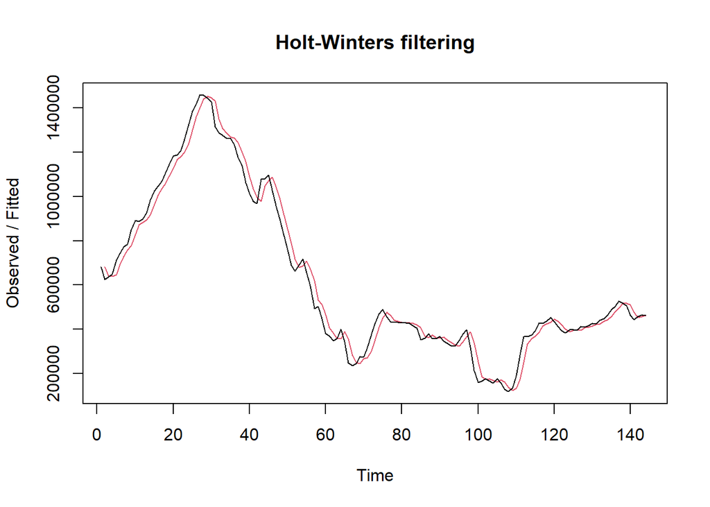

```r
ses2 <- HoltWinters(train.ts, gamma = FALSE, beta = FALSE, alpha = 0.7)
plot(ses2)
```

```r
ramalan2 <- forecast(ses2, h = h_forecast)
ramalan2
```

```
##     Point Forecast    Lo 80    Hi 80     Lo 95    Hi 95
## 145       463668.2 401049.8 526286.6 367901.63 559434.7
## 146       463668.2 387232.7 540103.6 346770.21 580566.1
## 147       463668.2 375556.3 551780.0 328912.70 598423.7
## 148       463668.2 365255.7 562080.7 313159.23 614177.1
## 149       463668.2 355935.4 571400.9 298905.18 628431.2
## 150       463668.2 347359.7 579976.7 285789.71 641546.6
## 151       463668.2 339374.2 587962.1 273577.01 653759.3
## 152       463668.2 331871.7 595464.6 262102.91 665233.4
## 153       463668.2 324773.9 602562.5 251247.70 676088.7
## 154       463668.2 318021.5 609314.8 240920.87 686415.5
## 155       463668.2 311568.7 615767.7 231052.04 696284.3
## 156       463668.2 305378.6 621957.7 221585.19 705751.2
## 157       463668.2 299421.7 627914.6 212474.88 714861.5
## 158       463668.2 293673.4 633662.9 203683.61 723652.7
```

[output cut: 22 more lines]

## Parameter Alpha Optimum

Nilai parameter alpha dapat dioptimalkan menyesuaikan error paling minimum, dengan membuat alpha = NULL.

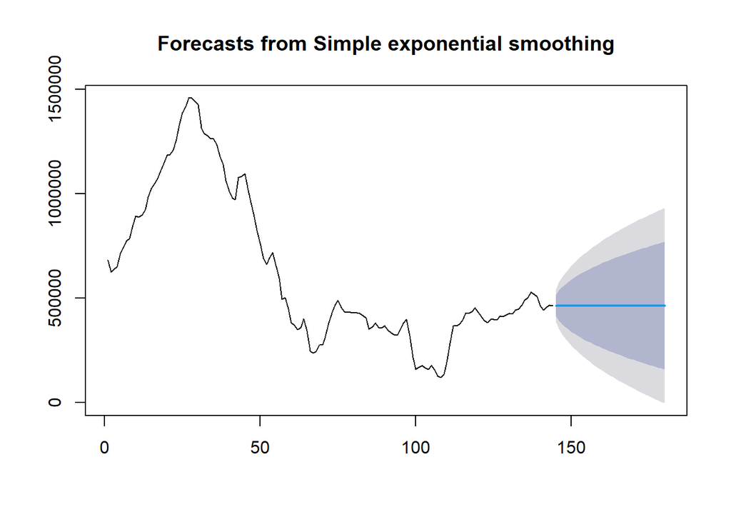

```r
ses.opt <- ses(train.ts, h = h_forecast, alpha = NULL)
plot(ses.opt)
```

```r
ses.opt
```

```
##     Point Forecast    Lo 80    Hi 80      Lo 95    Hi 95
## 145       463960.2 413042.6 514877.7 386088.438 541831.9
## 146       463960.2 391955.4 535964.9 353838.424 574081.9
## 147       463960.2 375774.2 552146.1 329091.378 598828.9
## 148       463960.2 362132.6 565787.7 308228.404 619691.9
## 149       463960.2 350114.1 577806.2 289847.635 638072.7
## 150       463960.2 339248.5 588671.8 273230.081 654690.2
## 151       463960.2 329256.5 598663.9 257948.620 669971.7
## 152       463960.2 319956.1 607964.2 243724.954 684195.4
## 153       463960.2 311221.0 616699.3 230365.773 697554.5
## 154       463960.2 302959.1 624961.2 217730.330 710190.0
## 155       463960.2 295101.0 632819.3 205712.371 722207.9
## 156       463960.2 287592.7 640327.6 194229.346 733691.0
## 157       463960.2 280391.2 647529.1 183215.608 744704.7
## 158       463960.2 273461.7 654458.6 172617.930 755302.4
```

[output cut: 22 more lines]

```r
HWopt <- HoltWinters(train.ts, gamma = FALSE, beta = FALSE, alpha = NULL)
HWopt
```

```
## Holt-Winters exponential smoothing without trend and without seasonal component.
##
## Call:
## HoltWinters(x = train.ts, alpha = NULL, beta = FALSE, gamma = FALSE)
##
## Smoothing parameters:
##  alpha: 0.9999286
##  beta : FALSE
##  gamma: FALSE
##
## Coefficients:
##       [,1]
## a 463960.1
```

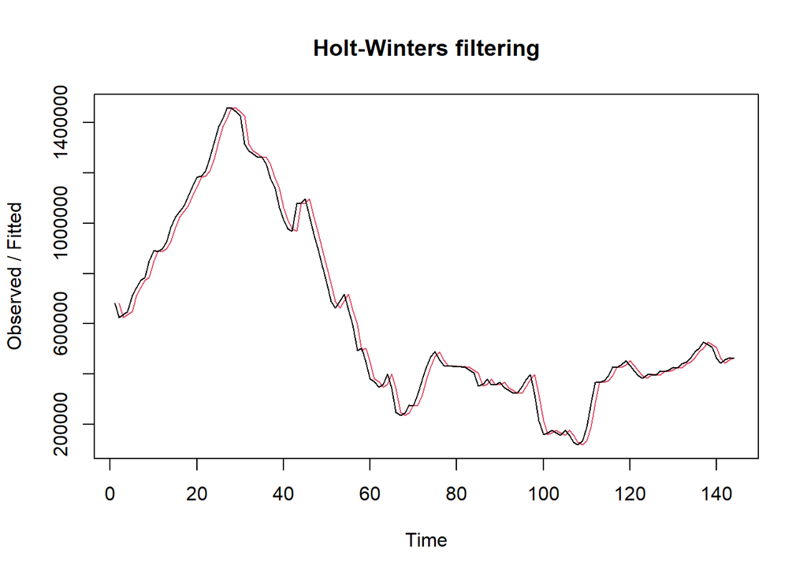

```r
plot(HWopt)
```

```r
ramalanopt <- forecast(HWopt, h = h_forecast)
ramalanopt
```

```
##     Point Forecast    Lo 80    Hi 80       Lo 95    Hi 95
## 145       463960.1 413409.2 514511.0 386649.1525 541271.1
## 146       463960.1 392472.9 535447.4 354629.8075 573290.4
## 147       463960.1 376407.5 551512.7 330059.9758 597860.2
## 148       463960.1 362863.7 565056.5 309346.4727 618573.7
## 149       463960.1 350931.3 576988.9 291097.4254 636822.8
## 150       463960.1 340143.5 587776.7 274598.9772 653321.2
## 151       463960.1 330223.1 597697.1 259427.0576 668493.2
## 152       463960.1 320989.5 606930.8 245305.3583 682614.9
## 153       463960.1 312317.0 615603.2 232041.9535 695878.3
## 154       463960.1 304114.3 623805.9 219497.1021 708423.1
## 155       463960.1 296312.6 631607.7 207565.3107 720354.9
## 156       463960.1 288858.1 639062.2 196164.6208 731755.6
## 157       463960.1 281708.2 646212.0 185229.8552 742690.4
## 158       463960.1 274828.4 653091.8 174708.1682 753212.1
```

[output cut: 22 more lines]

## Akurasi Data Latih

```r
#Keakuratan Metode - Pada data training
# SES dengan alpha = 0.2
SSE1  <- ses1$SSE
MSE1  <- ses1$SSE/length(train.ts)
RMSE1 <- sqrt(MSE1)

# SES dengan alpha = 0.7
SSE2  <- ses2$SSE
MSE2  <- ses2$SSE/length(train.ts)
RMSE2 <- sqrt(MSE2)

akurasi_train.ses <- data.frame(
  Skenario = c("alpha=0.2", "alpha=0.7"),
  SSE  = c(SSE1, SSE2),
  MSE  = c(MSE1, MSE2),
  RMSE = c(RMSE1, RMSE2)
)
akurasi_train.ses
```

```
##    Skenario          SSE         MSE      RMSE
## 1 alpha=0.2 1.723822e+12 11970986123 109412.00
## 2 alpha=0.7 3.396925e+11  2358975465  48569.29
```

## Akurasi Data Uji

```r
# error (ramalan - aktual)
e1   <- as.numeric(ramalan1$mean)[1:n_test] - as.numeric(testing$CPIAUCSL_PC1)
e2   <- as.numeric(ramalan2$mean)[1:n_test] - as.numeric(testing$CPIAUCSL_PC1)
eopt <- as.numeric(ramalanopt$mean)[1:n_test] - as.numeric(testing$CPIAUCSL_PC1)

SSEtesting1  <- sum(e1^2, na.rm = TRUE);  MSEtesting1  <- mean(e1^2, na.rm = TRUE);  RMSEtesting1  <- sqrt(MSEtesting1)
SSEtesting2  <- sum(e2^2, na.rm = TRUE);  MSEtesting2  <- mean(e2^2, na.rm = TRUE);  RMSEtesting2  <- sqrt(MSEtesting2)
SSEtestingopt<- sum(eopt^2, na.rm = TRUE);MSEtestingopt<- mean(eopt^2, na.rm = TRUE);RMSEtestingopt<- sqrt(MSEtestingopt)

akurasi_test.ses <- data.frame(
  Skenario = c("alpha=0.2", "alpha=0.7", "alpha optimum"),
  SSE  = c(SSEtesting1, SSEtesting2, SSEtestingopt),
  MSE  = c(MSEtesting1, MSEtesting2, MSEtestingopt),
  RMSE = c(RMSEtesting1, RMSEtesting2, RMSEtestingopt)
)
akurasi_test.ses
```

```
##        Skenario          SSE         MSE     RMSE
## 1     alpha=0.2 574149186456 15948588513 126287.7
## 2     alpha=0.7 560380167407 15566115761 124764.2
## 3 alpha optimum 561240046081 15590001280 124859.9
```

```r
# Atau menggunakan fungsi accuracy() dari package forecast
accuracy(ramalan1, testing$CPIAUCSL_PC1)
```

```
##                      ME     RMSE       MAE        MPE     MAPE     MASE
## Training set  -7458.537 109793.9  88070.99  -5.982956 18.10159 2.995184
## Test set     -45211.600 126287.7 108293.46 -19.637449 30.48787 3.682924
##                   ACF1
## Training set 0.9447588
## Test set            NA
```

```r
accuracy(ramalan2, testing$CPIAUCSL_PC1)
```

```
##                      ME      RMSE       MAE        MPE      MAPE     MASE
## Training set  -2175.453  48738.81  37559.34  -1.271837  7.750786 1.277346
## Test set     -40762.925 124764.24 108004.54 -18.500493 30.136484 3.673099
##                   ACF1
## Training set 0.7309229
## Test set            NA
```

```r
accuracy(ramalanopt, testing$CPIAUCSL_PC1)
```

```
##                      ME      RMSE       MAE         MPE      MAPE    MASE
## Training set  -1520.884  39336.34  29405.39  -0.7269984  6.222461 1.00004
## Test set     -41054.860 124859.93 108020.76 -18.5751037 30.158957 3.67365
##                   ACF1
## Training set 0.5623768
## Test set            NA
```

# Metode 4: Double Exponential Smoothing (DES)

DES digunakan untuk data yang memiliki pola tren. Prinsipnya seperti SES namun dilakukan dua kali, yaitu untuk tahap ‘level’ dan tahap ‘tren’. Kali ini argumen `beta` diinisialisasi bersamaan dengan `alpha`.

## Pemulusan

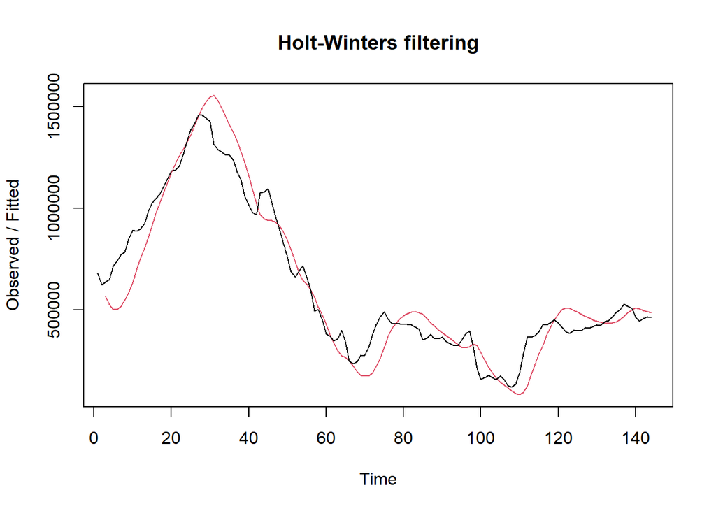

```r
# Skenario 1
des.1 <- HoltWinters(train.ts, gamma = FALSE, beta = 0.2, alpha = 0.2)
plot(des.1)
```

```r
ramalandes1 <- forecast(des.1, h = h_forecast)
ramalandes1
```

```
##     Point Forecast       Lo 80     Hi 80       Lo 95     Hi 95
## 145       482665.0  347447.719  617882.3  275868.009  689462.0
## 146       482761.4  343704.407  621818.5  270092.062  695430.8
## 147       482857.9  338738.814  626976.9  262446.797  703268.9
## 148       482954.3  332479.866  633428.7  252823.516  713085.1
## 149       483050.7  324898.507  641202.9  241177.782  724923.7
## 150       483147.1  316001.951  650292.3  227520.628  738773.7
## 151       483243.6  305825.302  660661.9  211905.740  754581.4
## 152       483340.0  294422.530  672257.5  194415.659  772264.4
## 153       483436.4  281858.336  685014.5  175149.337  791723.5
## 154       483532.9  268201.716  698864.0  154212.292  812853.4
## 155       483629.3  253521.402  713737.2  131709.644  835548.9
## 156       483725.7  237882.984  729568.5  107741.701  859709.7
## 157       483822.1  221347.309  746297.0   82401.523  885242.8
## 158       483918.6  203969.796  763867.4   55773.865  912063.3
```

[output cut: 22 more lines]

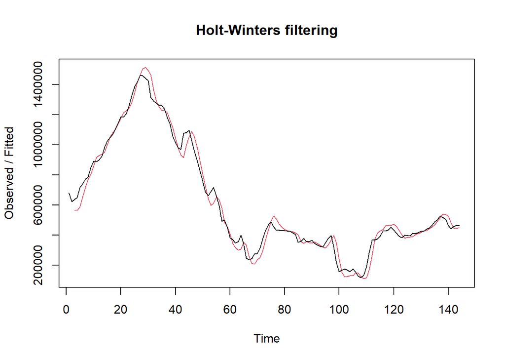

```r
# Skenario 2
des.2 <- HoltWinters(train.ts, gamma = FALSE, beta = 0.3, alpha = 0.6)
plot(des.2)
```

```r
ramalandes2 <- forecast(des.2, h = h_forecast)
ramalandes2
```

```
##     Point Forecast        Lo 80     Hi 80        Lo 95     Hi 95
## 145       455218.1   391441.391  518994.9   357680.020  552756.3
## 146       451570.5   370687.060  532453.9   327869.975  575270.9
## 147       447922.8   346479.656  549365.9   292778.909  603066.7
## 148       444275.1   319468.068  569082.1   253399.214  635151.0
## 149       440627.4   290081.878  591173.0   210387.879  670867.0
## 150       436979.7   258609.972  615349.5   164186.715  709772.8
## 151       433332.1   225255.608  641408.5   115106.582  751557.6
## 152       429684.4   190168.954  669199.8    63377.139  795991.6
## 153       426036.7   153465.911  698607.5     9175.643  842897.8
## 154       422389.0   115239.270  729538.8   -47355.995  892134.1
## 155       418741.4    75565.564  761917.2  -106100.728  943583.4
## 156       415093.7    34509.451  795677.9  -166959.671  997147.0
## 157       411446.0    -7873.376  830765.4  -229847.648 1052739.7
## 158       407798.3   -51534.185  867130.8  -294690.130 1110286.8
```

[output cut: 22 more lines]

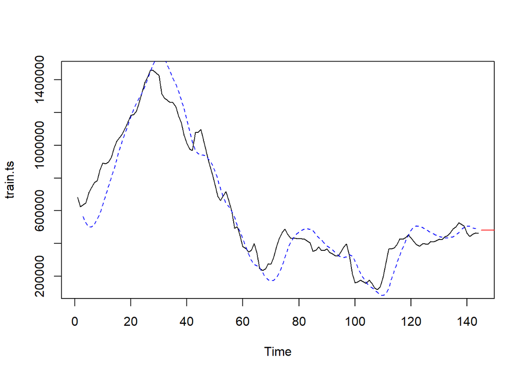

```r
plot(train.ts)
lines(des.1$fitted[,1], lty=2, col="blue")
lines(ramalandes1$mean, col="red")
```

## Parameter Optimum

```r
des.opt <- HoltWinters(train.ts, gamma = FALSE)
des.opt
```

```
## Holt-Winters exponential smoothing with trend and without seasonal component.
##
## Call:
## HoltWinters(x = train.ts, gamma = FALSE)
##
## Smoothing parameters:
##  alpha: 1
##  beta : 0.705227
##  gamma: FALSE
##
## Coefficients:
##          [,1]
## a 463960.0000
## b    664.5445
```

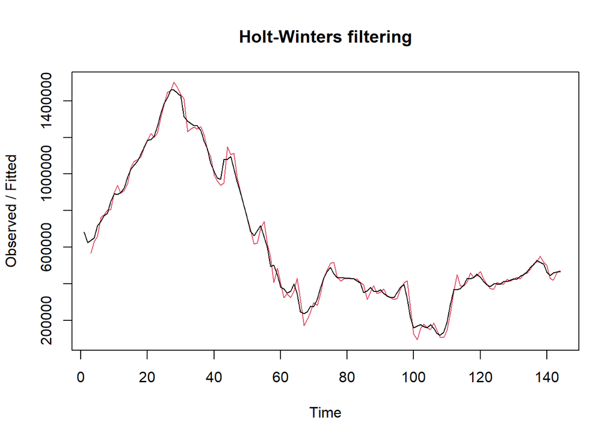

```r
plot(des.opt)
```

```r
ramalandesopt <- forecast(des.opt, h = h_forecast)
ramalandesopt
```

```
##     Point Forecast       Lo 80     Hi 80       Lo 95     Hi 95
## 145       464624.5   418604.53  510644.6   394243.01  535006.1
## 146       465289.1   374316.01  556262.2   326157.78  604420.4
## 147       465953.6   322491.54  609415.7   246547.29  685360.0
## 148       466618.2   263787.57  669448.8   156415.53  776820.8
## 149       467282.7   198844.01  735721.4    56741.13  877824.3
## 150       467947.3   128174.94  807719.6   -51689.67  987584.2
## 151       468611.8    52193.11  885030.5  -168245.63 1105469.3
## 152       469276.4   -28763.62  967316.3  -292410.06 1230962.8
## 153       469940.9  -114413.19 1054295.0  -423751.56 1363633.4
## 154       470605.4  -204515.86 1145726.8  -561903.50 1503114.4
## 155       471270.0  -298864.83 1241404.8  -706549.58 1649089.6
## 156       471934.5  -397279.42 1341148.5  -857413.49 1801282.6
## 157       472599.1  -499600.04 1444798.2 -1014251.16 1959449.3
## 158       473263.6  -605684.44 1552211.7 -1176845.05 2123372.3
```

[output cut: 22 more lines]

## Akurasi Data Latih

```r
ssedes.train1 <- des.1$SSE
msedes.train1 <- ssedes.train1/length(train.ts)
sisaandes1 <- ramalandes1$residuals
mapedes.train1 <- sum(abs(sisaandes1[3:length(train.ts)]/train.ts[3:length(train.ts)])*100,
                       na.rm = TRUE)/length(train.ts)

ssedes.train2 <- des.2$SSE
msedes.train2 <- ssedes.train2/length(train.ts)
sisaandes2 <- ramalandes2$residuals
mapedes.train2 <- sum(abs(sisaandes2[3:length(train.ts)]/train.ts[3:length(train.ts)])*100,
                       na.rm = TRUE)/length(train.ts)

akurasi_train.des <- data.frame(
  Skenario = c("alpha=0.2;beta=0.2", "alpha=0.6;beta=0.3"),
  SSE  = c(ssedes.train1, ssedes.train2),
  MSE  = c(msedes.train1, msedes.train2),
  MAPE = c(mapedes.train1, mapedes.train2)
)
akurasi_train.des
```

```
##             Skenario          SSE         MSE      MAPE
## 1 alpha=0.2;beta=0.2 1.584274e+12 11001905455 15.964607
## 2 alpha=0.6;beta=0.3 3.498279e+11  2429360612  8.241811
```

## Akurasi Data Uji

```r
selisihdes1 <- ramalandes1$mean - testing$CPIAUCSL_PC1
SSEtestingdes1  <- sum(selisihdes1^2)
MSEtestingdes1  <- SSEtestingdes1/length(testing$CPIAUCSL_PC1)
MAPEtestingdes1 <- sum(abs(selisihdes1/testing$CPIAUCSL_PC1)*100)/length(testing$CPIAUCSL_PC1)

selisihdes2 <- ramalandes2$mean - testing$CPIAUCSL_PC1
SSEtestingdes2  <- sum(selisihdes2^2)
MSEtestingdes2  <- SSEtestingdes2/length(testing$CPIAUCSL_PC1)
MAPEtestingdes2 <- sum(abs(selisihdes2/testing$CPIAUCSL_PC1)*100)/length(testing$CPIAUCSL_PC1)

selisihdesopt <- ramalandesopt$mean - testing$CPIAUCSL_PC1
SSEtestingdesopt  <- sum(selisihdesopt^2)
MSEtestingdesopt  <- SSEtestingdesopt/length(testing$CPIAUCSL_PC1)
MAPEtestingdesopt <- sum(abs(selisihdesopt/testing$CPIAUCSL_PC1)*100)/length(testing$CPIAUCSL_PC1)

akurasi_test.des <- data.frame(
  Skenario = c("alpha=0.2;beta=0.2", "alpha=0.6;beta=0.3", "optimum"),
  SSE  = c(SSEtestingdes1, SSEtestingdes2, SSEtestingdesopt),
  MSE  = c(MSEtestingdes1, MSEtestingdes2, MSEtestingdesopt),
  MAPE = c(MAPEtestingdes1, MAPEtestingdes2, MAPEtestingdesopt)
)
akurasi_test.des
```

```
##             Skenario          SSE         MSE     MAPE
## 1 alpha=0.2;beta=0.2 643396292042 17872119223 32.51106
## 2 alpha=0.6;beta=0.3 328121054439  9114473734 17.28325
## 3            optimum 652087009237 18113528034 32.62447
```

## Perbandingan SES vs DES

```r
MSEfull <- data.frame(
  Skenario = c("ske 1", "ske 2", "ske optimum"),
  SES = c(MSEtesting1, MSEtesting2, MSEtestingopt),
  DES = c(MSEtestingdes1, MSEtestingdes2, MSEtestingdesopt)
)
MSEfull
```

```
##      Skenario         SES         DES
## 1       ske 1 15948588513 17872119223
## 2       ske 2 15566115761  9114473734
## 3 ske optimum 15590001280 18113528034
```

# Perbandingan Seluruh Metode

Ringkasan akurasi data uji (MSE) dari SMA, DMA, SES, dan DES, untuk membantu menentukan metode terbaik bagi data yang digunakan.

```r
perbandingan_metode <- data.frame(
  Metode = c("SMA", "DMA",
             "SES (alpha=0.2)", "SES (alpha=0.7)", "SES (optimum)",
             "DES (ske 1)", "DES (ske 2)", "DES (optimum)"),
  MSE_Testing = c(MSE_test.sma, MSE_test.dma,
                  MSEtesting1, MSEtesting2, MSEtestingopt,
                  MSEtestingdes1, MSEtestingdes2, MSEtestingdesopt)
)
perbandingan_metode[order(perbandingan_metode$MSE_Testing), ]
```

```
##            Metode MSE_Testing
## 7     DES (ske 2)  9114473734
## 2             DMA 12146794482
## 1             SMA 15130777575
## 4 SES (alpha=0.7) 15566115761
## 5   SES (optimum) 15590001280
## 3 SES (alpha=0.2) 15948588513
## 6     DES (ske 1) 17872119223
## 8   DES (optimum) 18113528034
```

Berdasarkan hasil evaluasi pada data uji, DES skenario 2 (alpha = 0,6; beta = 0,3) terpilih sebagai metode pemulusan/peramalan terbaik karena menghasilkan nilai Mean Squared Error (MSE) terkecil dibanding metode yang lain.

MSE digunakan sebagai kriteria pemilihan karena secara statistik merepresentasikan rata-rata kuadrat galat (selisih) antara nilai hasil peramalan dan nilai aktual. Semakin kecil nilainya, semakin dekat pola hasil pemulusan/peramalan model terhadap data sebenarnya. Sehingga, model dengan MSE terendah dianggap memiliki tingkat kesalahan prediksi paling rendah dan generalisasi terbaik terhadap data di luar data latih.